# Danish Kings

Marius Hedegaard Henningsen, Soroosh Sabri, Malte Volquartzen

26-05-2026

## Load the kings

1. Look at the dataset that are you loading and check what its columns are separated by? (hint: open it in plain text editor to see)

List what is the separator: the kings data is comma-separated

2. Create a `kings` object in R with the different functions below and inspect the different outputs.
- `read.csv()`
- `read_csv()`
- `read.csv2()`
- `read_csv2()`

```r
library(tidyverse)
# FILL IN THE CODE BELOW and review the outputs

kings1 <- read.csv("data/kings.csv")

kings2 <- read_csv("data/kings.csv")
kings3 <- read.csv2("data/kings.csv")

kings4 <- read_csv2("data/kings.csv")
```

```
## ℹ Using "','" as decimal and "'.'" as grouping mark. Use `read_delim()` for more control.
```

```r
kings1
```

```
##                              Name                                    House
## 1                  Gorm den Gamle                                     Gorm
## 2               Harald 1. Blåtand                                     Gorm
## 3                    Toke_Gormsen                                     Gorm
## 4                Svend 1. Tveskæg                                     Gorm
## 5                       Harald 2.                                     Gorm
## 6               Knud 1. den Store                                     Gorm
## 7                       Hardeknud                                     Gorm
## 8                Magnus den Gode                                  Fairhair
## 9              Svend 2. Estridsen                                Estridsen
## 10                 Harald 3. Hen                                 Estridsen
## 11           Knud 2. den Hellige                                 Estridsen
## 12                Oluf 1. Hunger                                 Estridsen
## 13                Erik 1. Ejegod                                 Estridsen
## 14                          Niels                                Estridsen
```

[output cut: 159 more lines]

```r
glimpse(kings1)
```

```
## Rows: 57
## Columns: 11
## $ Name       <chr> "Gorm den Gamle", "Harald 1. Blåtand", "Toke_Gormsen", "Sve…
## $ House      <chr> "Gorm", "Gorm", "Gorm", "Gorm", "Gorm", "Gorm", "Gorm", "Fa…
## $ Start_year <chr> "936", "NULL", "985", "NULL", "1014", "1018", "1035", "1042…
## $ End_year   <chr> "958", "NULL", "986", "NULL", "1018", "1035", "1042", "1047…
## $ Birth_year <chr> "908", "936", "NULL", "NULL", "963", "NULL", "995", "1018",…
## $ Death_year <chr> "958", "985", "986", "1014", "NULL", "1035", "1042", "1047"…
## $ Gender     <chr> "M", "M ", "M ", "M ", "M ", "M ", "M ", "M ", "M ", "M ", …
## $ Dynasty    <chr> "Jellingdynastiet", "Jellingdynastiet", "Jellingdynastiet",…
## $ Source     <chr> "https://da.wikipedia.org/wiki/Gorm_den_Gamle", "https://da…
## $ BirthDMY   <chr> "908", "936", "", "17/04/963", "994", "995", "1018", "1024"…
## $ DeathDMY   <chr> "958", "987", "", "03/02/1014", "1018", "12/11/1035", "08/0…
```

```r
class(kings1)
```

```
## [1] "data.frame"
```

```r
head(kings1)
```

```
##                Name House Start_year End_year Birth_year Death_year Gender
## 1    Gorm den Gamle  Gorm        936      958        908        958      M
## 2 Harald 1. Blåtand  Gorm       NULL     NULL        936        985     M
## 3      Toke_Gormsen  Gorm        985      986       NULL        986     M
## 4  Svend 1. Tveskæg  Gorm       NULL     NULL       NULL       1014     M
## 5         Harald 2.  Gorm       1014     1018        963       NULL     M
## 6 Knud 1. den Store  Gorm       1018     1035       NULL       1035     M
##            Dynasty                                            Source  BirthDMY
## 1 Jellingdynastiet      https://da.wikipedia.org/wiki/Gorm_den_Gamle       908
## 2 Jellingdynastiet https://da.wikipedia.org/wiki/Harald_Bl%C3%A5tand       936
## 3 Jellingdynastiet        https://da.wikipedia.org/wiki/Toke_Gormsen
## 4 Jellingdynastiet  https://da.wikipedia.org/wiki/Svend_Tvesk%C3%A6g 17/04/963
## 5 Jellingdynastiet           https://da.wikipedia.org/wiki/Harald_2.       994
## 6 Jellingdynastiet      https://da.wikipedia.org/wiki/Knud_den_Store       995
##     DeathDMY
## 1        958
## 2        987
## 3
## 4 03/02/1014
## 5       1018
## 6 12/11/1035
```

```r
kings2
```

```
## # A tibble: 57 × 11
##    Name    House Start_year End_year Birth_year Death_year Gender Dynasty Source
##    <chr>   <chr> <chr>      <chr>    <chr>      <chr>      <chr>  <chr>   <chr>
##  1 Gorm d… Gorm  936        958      908        958        M      Jellin… https…
##  2 Harald… Gorm  NULL       NULL     936        985        M      Jellin… https…
##  3 Toke_G… Gorm  985        986      NULL       986        M      Jellin… https…
##  4 Svend … Gorm  NULL       NULL     NULL       1014       M      Jellin… https…
##  5 Harald… Gorm  1014       1018     963        NULL       M      Jellin… https…
##  6 Knud 1… Gorm  1018       1035     NULL       1035       M      Jellin… https…
##  7 Hardek… Gorm  1035       1042     995        1042       M      Jellin… https…
##  8 Magnus… Fair… 1042       1047     1018       1047       M      Jellin… https…
##  9 Svend … Estr… 1047       1074     1024       1076       M      <NA>    https…
## 10 Harald… Estr… 1074       1080     1019       1080       M      Jellin… https…
## # ℹ 47 more rows
## # ℹ 2 more variables: BirthDMY <chr>, DeathDMY <chr>
```

```r
glimpse(kings2)
```

```
## Rows: 57
## Columns: 11
## $ Name       <chr> "Gorm den Gamle", "Harald 1. Blåtand", "Toke_Gormsen", "Sve…
## $ House      <chr> "Gorm", "Gorm", "Gorm", "Gorm", "Gorm", "Gorm", "Gorm", "Fa…
## $ Start_year <chr> "936", "NULL", "985", "NULL", "1014", "1018", "1035", "1042…
## $ End_year   <chr> "958", "NULL", "986", "NULL", "1018", "1035", "1042", "1047…
## $ Birth_year <chr> "908", "936", "NULL", "NULL", "963", "NULL", "995", "1018",…
## $ Death_year <chr> "958", "985", "986", "1014", "NULL", "1035", "1042", "1047"…
## $ Gender     <chr> "M", "M", "M", "M", "M", "M", "M", "M", "M", "M", "M", "M",…
## $ Dynasty    <chr> "Jellingdynastiet", "Jellingdynastiet", "Jellingdynastiet",…
## $ Source     <chr> "https://da.wikipedia.org/wiki/Gorm_den_Gamle", "https://da…
## $ BirthDMY   <chr> "908", "936", NA, "17/04/963", "994", "995", "1018", "1024"…
## $ DeathDMY   <chr> "958", "987", NA, "03/02/1014", "1018", "12/11/1035", "08/0…
```

```r
class(kings2)
```

```
## [1] "spec_tbl_df" "tbl_df"      "tbl"         "data.frame"
```

```r
head(kings1)
```

```
##                Name House Start_year End_year Birth_year Death_year Gender
## 1    Gorm den Gamle  Gorm        936      958        908        958      M
## 2 Harald 1. Blåtand  Gorm       NULL     NULL        936        985     M
## 3      Toke_Gormsen  Gorm        985      986       NULL        986     M
## 4  Svend 1. Tveskæg  Gorm       NULL     NULL       NULL       1014     M
## 5         Harald 2.  Gorm       1014     1018        963       NULL     M
## 6 Knud 1. den Store  Gorm       1018     1035       NULL       1035     M
##            Dynasty                                            Source  BirthDMY
## 1 Jellingdynastiet      https://da.wikipedia.org/wiki/Gorm_den_Gamle       908
## 2 Jellingdynastiet https://da.wikipedia.org/wiki/Harald_Bl%C3%A5tand       936
## 3 Jellingdynastiet        https://da.wikipedia.org/wiki/Toke_Gormsen
## 4 Jellingdynastiet  https://da.wikipedia.org/wiki/Svend_Tvesk%C3%A6g 17/04/963
## 5 Jellingdynastiet           https://da.wikipedia.org/wiki/Harald_2.       994
## 6 Jellingdynastiet      https://da.wikipedia.org/wiki/Knud_den_Store       995
##     DeathDMY
## 1        958
## 2        987
## 3
## 4 03/02/1014
## 5       1018
## 6 12/11/1035
```

```r
kings3
```

```
##                                                                      Name.House.Start_year.End_year.Birth_year.Death_year.Gender.Dynasty.Source.BirthDMY.DeathDMY
## 1                                                     Gorm den Gamle,Gorm,936,958,908,958,M,Jellingdynastiet,https://da.wikipedia.org/wiki/Gorm_den_Gamle,908,958
## 2                                          Harald 1. Blåtand,Gorm,NULL,NULL,936,985,M ,Jellingdynastiet,https://da.wikipedia.org/wiki/Harald_Bl%C3%A5tand,936,987
## 3                                                             Toke_Gormsen,Gorm,985,986,NULL,986,M ,Jellingdynastiet,https://da.wikipedia.org/wiki/Toke_Gormsen,,
## 4                             Svend 1. Tveskæg,Gorm,NULL,NULL,NULL,1014,M ,Jellingdynastiet,https://da.wikipedia.org/wiki/Svend_Tvesk%C3%A6g,17/04/963,03/02/1014
## 5                                                          Harald 2.,Gorm,1014,1018,963,NULL,M ,Jellingdynastiet,https://da.wikipedia.org/wiki/Harald_2.,994,1018
## 6                                      Knud 1. den Store,Gorm,1018,1035,NULL,1035,M ,Jellingdynastiet,https://da.wikipedia.org/wiki/Knud_den_Store,995,12/11/1035
## 7                                                   Hardeknud,Gorm,1035,1042,995,1042,M ,Jellingdynastiet,https://da.wikipedia.org/wiki/Hardeknud,1018,08/06/1042
## 8                                 Magnus den Gode ,Fairhair,1042,1047,1018,1047,M ,Jellingdynastiet,https://da.wikipedia.org/wiki/Magnus_den_Gode,1024,25/10/1047
## 9                                              Svend 2. Estridsen,Estridsen,1047,1074,1024,1076,M ,,https://da.wikipedia.org/wiki/Svend_Estridsen,1019,28/04/1076
## 10                                      Harald 3. Hen ,Estridsen,1074,1080,1019,1080,M ,Jellingdynastiet,https://da.wikipedia.org/wiki/Harald_Hen,1041,17/04/1080
## 11                          Knud 2. den Hellige ,Estridsen,1080,1086,1041,1086,M ,Jellingdynastiet,https://da.wikipedia.org/wiki/Knud_den_Hellige,1043,10/07/1086
## 12                                    Oluf 1. Hunger ,Estridsen,1086,1095,1043,1095,M ,Jellingdynastiet,https://da.wikipedia.org/wiki/Oluf_Hunger,1050,18/08/1095
## 13                                    Erik 1. Ejegod ,Estridsen,1095,1103,1050,1103,M ,Jellingdynastiet,https://da.wikipedia.org/wiki/Erik_Ejegod,1055,10/07/1103
## 14                                         Niels,Estridsen,1104,1134,1055,1134,M ,Jellingdynastiet,https://da.wikipedia.org/wiki/Niels_af_Danmark,1134,25/06/1134
```

[output cut: 45 more lines]

```r
glimpse(kings3)
```

```
## Rows: 59
## Columns: 1
## $ Name.House.Start_year.End_year.Birth_year.Death_year.Gender.Dynasty.Source.BirthDMY.DeathDMY <chr> …
```

```r
class(kings3)
```

```
## [1] "data.frame"
```

```r
head(kings3)
```

```
##                                          Name.House.Start_year.End_year.Birth_year.Death_year.Gender.Dynasty.Source.BirthDMY.DeathDMY
## 1                         Gorm den Gamle,Gorm,936,958,908,958,M,Jellingdynastiet,https://da.wikipedia.org/wiki/Gorm_den_Gamle,908,958
## 2              Harald 1. Blåtand,Gorm,NULL,NULL,936,985,M ,Jellingdynastiet,https://da.wikipedia.org/wiki/Harald_Bl%C3%A5tand,936,987
## 3                                 Toke_Gormsen,Gorm,985,986,NULL,986,M ,Jellingdynastiet,https://da.wikipedia.org/wiki/Toke_Gormsen,,
## 4 Svend 1. Tveskæg,Gorm,NULL,NULL,NULL,1014,M ,Jellingdynastiet,https://da.wikipedia.org/wiki/Svend_Tvesk%C3%A6g,17/04/963,03/02/1014
## 5                              Harald 2.,Gorm,1014,1018,963,NULL,M ,Jellingdynastiet,https://da.wikipedia.org/wiki/Harald_2.,994,1018
## 6          Knud 1. den Store,Gorm,1018,1035,NULL,1035,M ,Jellingdynastiet,https://da.wikipedia.org/wiki/Knud_den_Store,995,12/11/1035
```

```r
kings4
```

```
## # A tibble: 57 × 1
##    Name,House,Start_year,End_year,Birth_year,Death_year,Gender,Dynasty,Source,…¹
##    <chr>
##  1 Gorm den Gamle,Gorm,936,958,908,958,M,Jellingdynastiet,https://da.wikipedia.…
##  2 Harald 1. Blåtand,Gorm,NULL,NULL,936,985,M ,Jellingdynastiet,https://da.wiki…
##  3 Toke_Gormsen,Gorm,985,986,NULL,986,M ,Jellingdynastiet,https://da.wikipedia.…
##  4 Svend 1. Tveskæg,Gorm,NULL,NULL,NULL,1014,M ,Jellingdynastiet,https://da.wik…
##  5 Harald 2.,Gorm,1014,1018,963,NULL,M ,Jellingdynastiet,https://da.wikipedia.o…
##  6 Knud 1. den Store,Gorm,1018,1035,NULL,1035,M ,Jellingdynastiet,https://da.wi…
##  7 Hardeknud,Gorm,1035,1042,995,1042,M ,Jellingdynastiet,https://da.wikipedia.o…
##  8 Magnus den Gode ,Fairhair,1042,1047,1018,1047,M ,Jellingdynastiet,https://da…
##  9 Svend 2. Estridsen,Estridsen,1047,1074,1024,1076,M ,,https://da.wikipedia.or…
## 10 Harald 3. Hen ,Estridsen,1074,1080,1019,1080,M ,Jellingdynastiet,https://da.…
## # ℹ 47 more rows
## # ℹ abbreviated name:
## #   ¹`Name,House,Start_year,End_year,Birth_year,Death_year,Gender,Dynasty,Source,BirthDMY,DeathDMY`
```

```r
glimpse(kings4)
```

```
## Rows: 57
## Columns: 1
## $ `Name,House,Start_year,End_year,Birth_year,Death_year,Gender,Dynasty,Source,BirthDMY,DeathDMY` <chr> …
```

```r
class(kings4)
```

```
## [1] "spec_tbl_df" "tbl_df"      "tbl"         "data.frame"
```

```r
head(kings4)
```

```
## # A tibble: 6 × 1
##   Name,House,Start_year,End_year,Birth_year,Death_year,Gender,Dynasty,Source,B…¹
##   <chr>
## 1 Gorm den Gamle,Gorm,936,958,908,958,M,Jellingdynastiet,https://da.wikipedia.o…
## 2 Harald 1. Blåtand,Gorm,NULL,NULL,936,985,M ,Jellingdynastiet,https://da.wikip…
## 3 Toke_Gormsen,Gorm,985,986,NULL,986,M ,Jellingdynastiet,https://da.wikipedia.o…
## 4 Svend 1. Tveskæg,Gorm,NULL,NULL,NULL,1014,M ,Jellingdynastiet,https://da.wiki…
## 5 Harald 2.,Gorm,1014,1018,963,NULL,M ,Jellingdynastiet,https://da.wikipedia.or…
## 6 Knud 1. den Store,Gorm,1018,1035,NULL,1035,M ,Jellingdynastiet,https://da.wik…
## # ℹ abbreviated name:
## #   ¹`Name,House,Start_year,End_year,Birth_year,Death_year,Gender,Dynasty,Source,BirthDMY,DeathDMY`
```

Answer: 1. Which of these functions is a `tidyverse` function? Read data with it below into a `kings` object

read_csv() and read_csv2() are `tidyverse` functions

2. What is the result of running `class()` on the `kings` object created with a tidyverse function.

you get this result: “spec_tbl_df” “tbl_df” “tbl” “data.frame” This means that R reads the data as a tibble

3. How many columns does the object have when created with these different functions?

In the cases of read.csv and read_csv the object creates 11 columns In the cases of read.csv2 and read_csv2 the object creates 1 column

4. Show the dataset so that we can see how R interprets each column

We use the command glimpse(kings) which shows us that R reads the columns correctly with chr meaning that the values are read as characters and dbl meaning that the values are read as numbers

```r
# COMPLETE THE BLANKS BELOW WITH YOUR CODE, then turn the 'eval' flag in this chunk to TRUE.

kings <- read_csv("data/kings.csv", na = c("NULL",""))
# this is the right function for my dataset

class(kings)
```

```
## [1] "spec_tbl_df" "tbl_df"      "tbl"         "data.frame"
```

```r
glimpse(kings)
```

```
## Rows: 57
## Columns: 11
## $ Name       <chr> "Gorm den Gamle", "Harald 1. Blåtand", "Toke_Gormsen", "Sve…
## $ House      <chr> "Gorm", "Gorm", "Gorm", "Gorm", "Gorm", "Gorm", "Gorm", "Fa…
## $ Start_year <dbl> 936, NA, 985, NA, 1014, 1018, 1035, 1042, 1047, 1074, 1080,…
## $ End_year   <dbl> 958, NA, 986, NA, 1018, 1035, 1042, 1047, 1074, 1080, 1086,…
## $ Birth_year <dbl> 908, 936, NA, NA, 963, NA, 995, 1018, 1024, 1019, 1041, 104…
## $ Death_year <dbl> 958, 985, 986, 1014, NA, 1035, 1042, 1047, 1076, 1080, 1086…
## $ Gender     <chr> "M", "M", "M", "M", "M", "M", "M", "M", "M", "M", "M", "M",…
## $ Dynasty    <chr> "Jellingdynastiet", "Jellingdynastiet", "Jellingdynastiet",…
## $ Source     <chr> "https://da.wikipedia.org/wiki/Gorm_den_Gamle", "https://da…
## $ BirthDMY   <chr> "908", "936", NA, "17/04/963", "994", "995", "1018", "1024"…
## $ DeathDMY   <chr> "958", "987", NA, "03/02/1014", "1018", "12/11/1035", "08/0…
```

```r
head(kings)
```

```
## # A tibble: 6 × 11
##   Name     House Start_year End_year Birth_year Death_year Gender Dynasty Source
##   <chr>    <chr>      <dbl>    <dbl>      <dbl>      <dbl> <chr>  <chr>   <chr>
## 1 Gorm de… Gorm         936      958        908        958 M      Jellin… https…
## 2 Harald … Gorm          NA       NA        936        985 M      Jellin… https…
## 3 Toke_Go… Gorm         985      986         NA        986 M      Jellin… https…
## 4 Svend 1… Gorm          NA       NA         NA       1014 M      Jellin… https…
## 5 Harald … Gorm        1014     1018        963         NA M      Jellin… https…
## 6 Knud 1.… Gorm        1018     1035         NA       1035 M      Jellin… https…
## # ℹ 2 more variables: BirthDMY <chr>, DeathDMY <chr>
```

## Calculate the duration of reign for all the kings in your table

Create a new column called `duration` in the kings dataset, utilizing the `mutate()` function from tidyverse. Check with your group to brainstorm the options.

```r
# OUR CODE

kings <- kings %>%
  mutate(Start_year = as.numeric(Start_year), End_year = as.numeric(End_year))

kings <- kings %>%
  mutate(Duration = End_year - Start_year)



top_3 <- sort(kings$Duration, decreasing = TRUE)[1:3]

top_3
```

```
## [1] 60 51 43
```

## Calculate the average duration of reign for all rulers

```r
# OUR CODE

library(tidyverse)

# Tibble way

avg_reign <- kings %>%
  summarize(mean_duration = mean(Duration, na.rm = TRUE))

# Vector way

avg_reign_vector <- mean(kings$Duration, na.rm = TRUE)

print(avg_reign)
```

```
## # A tibble: 1 × 1
##   mean_duration
##           <dbl>
## 1          19.6
```

## How many and which kings enjoyed a longer-than-average duration of reign?

```r
# OUR CODE


#1 Finds the kings who enjoyed a longer-than-average duration of reign
long_reigns <- kings %>%
  filter(Duration > avg_reign_vector)
long_reigns
```

```
## # A tibble: 25 × 12
##    Name    House Start_year End_year Birth_year Death_year Gender Dynasty Source
##    <chr>   <chr>      <dbl>    <dbl>      <dbl>      <dbl> <chr>  <chr>   <chr>
##  1 Gorm d… Gorm         936      958        908        958 M      Jellin… https…
##  2 Svend … Estr…       1047     1074       1024       1076 M      <NA>    https…
##  3 Niels   Estr…       1104     1134       1055       1134 M      Jellin… https…
##  4 Valdem… Estr…       1157     1182       1131       1182 M      Jellin… https…
##  5 Knud 4. Estr…       1182     1202       1163       1202 M      Jellin… https…
##  6 Valdem… Estr…       1202     1241       1170       1241 M      Jellin… https…
##  7 Erik 5… Estr…       1259     1286       1249       1286 M      Jellin… https…
##  8 Erik 6… Estr…       1286     1319       1274       1319 M      Jellin… https…
##  9 Valdem… Estr…       1340     1375       1320       1375 M      Jellin… https…
## 10 Erik 7… Pome…       1396     1439       1382       1459 M      Jellin… https…
## # ℹ 15 more rows
## # ℹ 3 more variables: BirthDMY <chr>, DeathDMY <chr>, Duration <dbl>
```

```r
#2 Shows which kings enjoyed a longer-than-average duration of reign
long_reigns %>%
  select(Name, Duration) %>%
  arrange(desc(Duration))
```

```
## # A tibble: 25 × 2
##    Name                 Duration
##    <chr>                   <dbl>
##  1 Christian 4.               60
##  2 Margrete 2.                51
##  3 Erik 7. af Pommern         43
##  4 Christian 9.               43
##  5 Christian 7.               42
##  6 Valdemar 2. Sejr           39
##  7 Valdemar 4. Atterdag       35
##  8 Christian 10.              35
##  9 Erik 6. Menved             33
## 10 Chrstian 1.                33
## # ℹ 15 more rows
```

```r
# 5. Counts how many kings enjoyed a longer-than-average duration of reign
long_reigns %>%
  count()
```

```
## # A tibble: 1 × 1
##       n
##   <int>
## 1    25
```

## How many days did the three longest-ruling monarchs rule?

```r
# OUR CODE

top_3_monarchs <- kings %>%
  arrange(desc(Duration)) %>%
  slice(1:3) %>%
  mutate(
    Days_Basic = Duration * 365,
    # To count transition/leap year we add 0.25 to the 365 days, because every fourth year is a leap year
    Days_Leap = Duration * 365.25
  )

print(top_3_monarchs %>% select(Name, Duration, Days_Leap))
```

```
## # A tibble: 3 × 3
##   Name               Duration Days_Leap
##   <chr>                 <dbl>     <dbl>
## 1 Christian 4.             60    21915
## 2 Margrete 2.              51    18628.
## 3 Erik 7. af Pommern       43    15706.
```

## Challenge: Plot the kings’ duration of reign through time

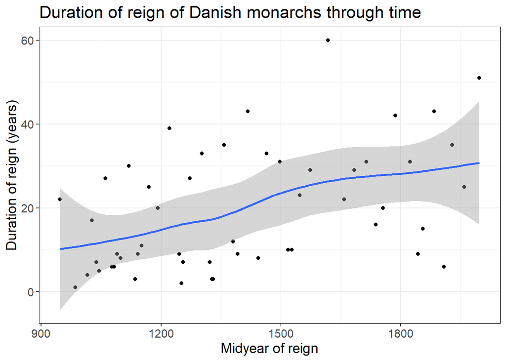

```r
# OUR CODE

kings <- kings |>
  mutate(Midyear = Start_year + (End_year - Start_year) / 2)

ggplot(kings, aes(x = Midyear, y = Duration)) +
  geom_point() +
  geom_smooth() +
  labs(
    title = "Duration of reign of Danish monarchs through time",
    x = "Midyear of reign",
    y = "Duration of reign (years)"
  ) +
  theme_bw() +
  theme(text = element_text(size = 14))
```